# Opgave-1

2024-09-20

♣

# Initialize

```r
# Import libraries
library("ggplot2")
library("tidyverse")
library("isdals")

# Load data
data("tartar")
```

# Opgave 1 (HS.18)

## Opgave 1

```r
head(tartar, n = 3)
```

```
##     treat index
## 1 Control  0.49
## 2 Control  1.05
## 3 Control  0.79
```

Vi har en kategorisk forklarende variabel og en kvantitativ kontinuert variabel. Derfor bruger vi Anova til at analysere påvirkningen på gennemsittet givet variablen treat.

```r
# refactor to make control group the primary group
tartar$treat <- relevel(factor(tartar$treat), ref="Control")
m1 <- lm(index ~ treat , data = tartar)
```

## Opgave 2

Model antagelse: Data: $(y_1, x_1) , ..., (y_26, x_26)$ hvor responsvariablen y et index på hvor høj en grad hunden har problemer med tandsten og og den diskrete forklarende variable x angiver de forskellige typer af behandlinger. Svarende til to behandlinger og en kontrol gruppe.

### Er data normalt fordelt?

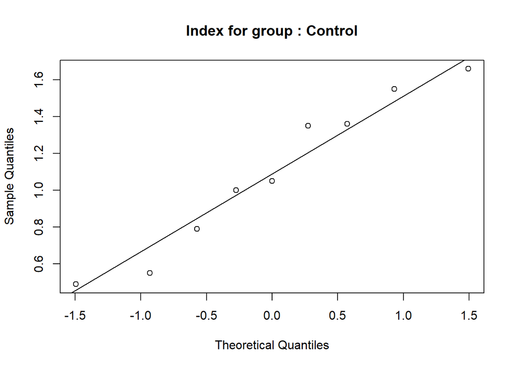

```r
tartar_contol <- subset(tartar, treat=="Control")
tartar_P207 <- subset(tartar, treat=="P2O7")
tartar_HMP <- subset(tartar, treat=="HMP")

qqnorm(tartar_contol$index, main = "Index for group : Control")
abline(a = mean(tartar_contol$index), b = sd(tartar_contol$index))
```

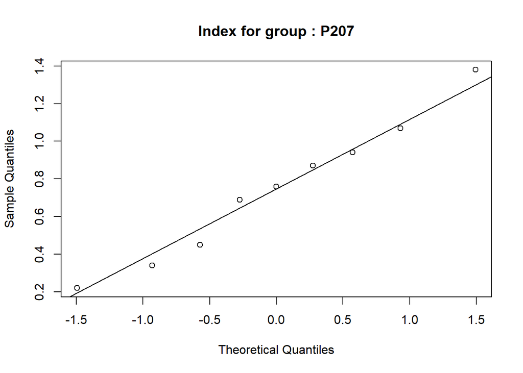

```r
qqnorm(tartar_P207$index, main = "Index for group : P207")
abline(a = mean(tartar_P207$index), b = sd(tartar_P207$index))
```

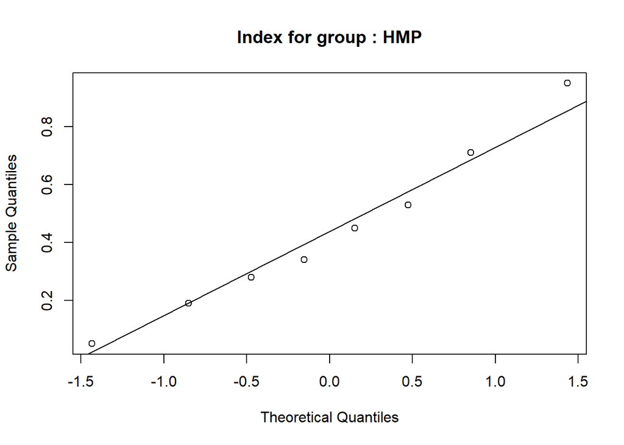

```r
qqnorm(tartar_HMP$index, main = "Index for group : HMP")
abline(a = mean(tartar_HMP$index), b = sd(tartar_HMP$index))
```

Vi kan se på QQ-plottet at der ikke er nogen systematisk afvigelse fra identitets linjen, hvilket tyder på at data falder i de kvartiler, som der forventes ved en normalfordeling.

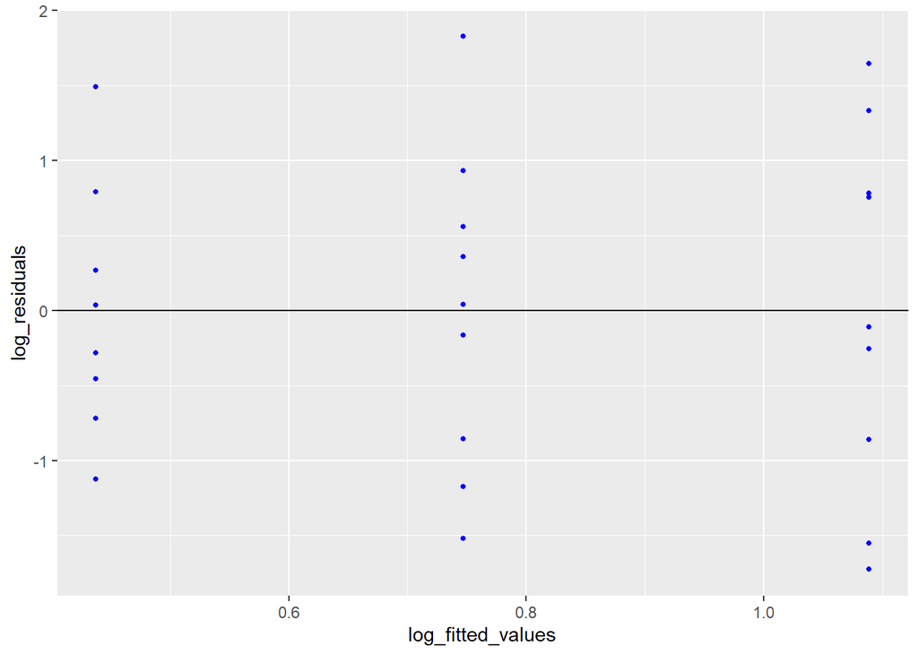

```r
m2 <- lm(index ~ treat, data = tartar)

tartar$log_fitted_values <- fitted(m2)
tartar$log_residuals <- rstandard(m2)

ggplot(data = tartar, aes(x = log_fitted_values, y = log_residuals)) +
  geom_point(color = "blue", size = 1) + # Scatter
  geom_abline(slope = 0, intercept = 0) # line
```

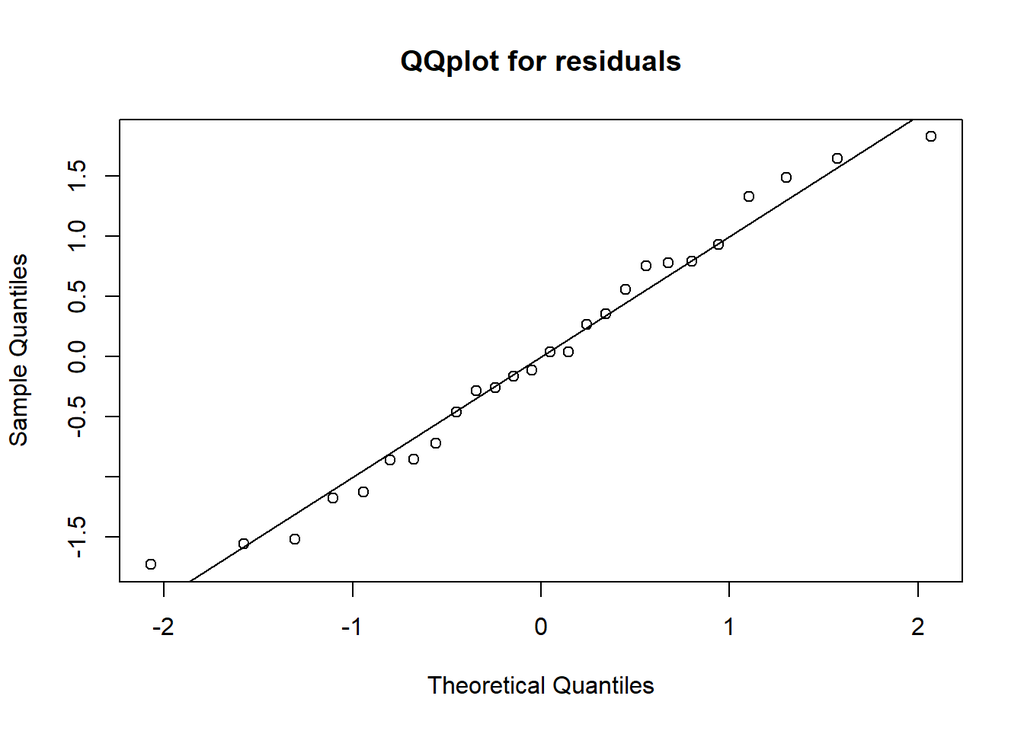

```r
qqnorm(tartar$log_residuals, main = "QQplot for residuals")
abline(a = 0, b = 1)
```

Antagelsen om at $e_1 ,.., e_n$ er standard normalt fordelt holder, der er ca. lige mange punkter over og under den vandrette linje på residualplottet. Og i QQ-plotet ser vi ingen systematisk afvigelse fra den ligefrem propotionalle linje. Herved validere vi at antagelse om spredningen er den samme for alle grupper.

### Afhænger middelværi af gruppen

Boxplot

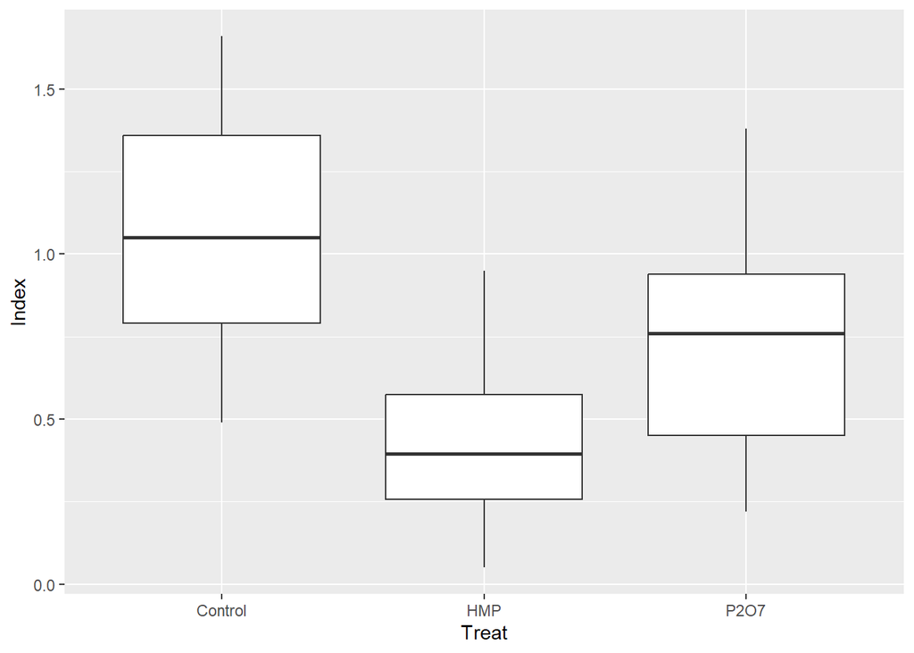

```r
## Boxplot
ggplot(data = tartar, aes(x = treat, y = index)) +
  geom_boxplot(outliers = TRUE) +
  xlab("Treat") + ylab("Index")
```

Plottet viser at der er en markant between-group variation, hvilket tyder på at den forklarende variabel har en påvirkning af på værdien af responsvariablen.

Dertil ser vi en større witihn-group variation i control og P207, end vi ser for HMP.

## Opgave 3

Vi bruger LM til at udregne estimatet for den forventede værdi $\hat{\mu}$

```r
m2 <- lm(index ~ treat -1 , data = tartar)
summary(m2)
```

```
##
## Call:
## lm(formula = index ~ treat - 1, data = tartar)
##
## Residuals:
##      Min       1Q   Median       3Q      Max
## -0.59889 -0.28437 -0.01319  0.26861  0.63333
##
## Coefficients:
##              Estimate Std. Error t value Pr(>|t|)
## treatControl   1.0889     0.1226   8.881 6.83e-09 ***
## treatHMP       0.4375     0.1301   3.364  0.00268 **
## treatP2O7      0.7467     0.1226   6.090 3.27e-06 ***
## ---
## Signif. codes:  0 '***' 0.001 '**' 0.01 '*' 0.05 '.' 0.1 ' ' 1
##
## Residual standard error: 0.3678 on 23 degrees of freedom
## Multiple R-squared:  0.8469, Adjusted R-squared:  0.827
## F-statistic: 42.42 on 3 and 23 DF,  p-value: 1.547e-09
```

Vi forventer at en hund som ikke er blevet behandlet har et index på 1.0889 Vi forventer at en hund som er blevet behandlet med P207 harr et index på 0.7467

## Opgave 4

$$H_0 : \alpha_1 = \alpha_2 = \alpha_2$$

- *fuld model*: ensidet anova med 3 gruppegennemsnit
- *nulmodel*: model hvor data opfattes som en sample fra en gruppe, altså hvor alle gruppegennemsnit antages at være ens

```r
n_groups <- 3
lenght <- nrow(tartar)
```

```r
fullModel <- lm(index ~ treat , data = tartar)
nulModel <- lm(index ~ 1 , data = tartar)
anova(nulModel, fullModel)
```

```
## Analysis of Variance Table
##
## Model 1: index ~ 1
## Model 2: index ~ treat
##   Res.Df    RSS Df Sum of Sq      F   Pr(>F)
## 1     25 4.9166
## 2     23 3.1120  2    1.8046 6.6684 0.005198 **
## ---
## Signif. codes:  0 '***' 0.001 '**' 0.01 '*' 0.05 '.' 0.1 ' ' 1
```

```r
1 - pf(6.6684, 3-1, 28-5)
```

```
## [1] 0.005198563
```

Vi anvender F-test til at sige noget om gennemsnittet på tværs af alle grupper, ved at sammenligne mellem-grupe variationen med indenfor-gruppe variationen. Da p-værdien for f-statistic er mindre end 0.05 forkastes nul-hypotesen på et signifikansnivue på 95%, for at alle middelværdier er nes.

Der er altså mindst en af grupperne, hvis middelværedi afviger fra kontrol gruppen.

## Opgave 5

```r
confint(m1)
```

```
##                  2.5 %      97.5 %
## (Intercept)  0.8352441  1.34253368
## treatHMP    -1.0211365 -0.28164124
## treatP2O7   -0.7009301  0.01648568
```

Vi kan med 95% sikkerhed konkludere at den sande forskel ligger i intervallet (-1.0211365, -0.28164124). Da 0 ikke indgår i intervallet er der evidens for at HMP behandlingen virker.

# Opgave Eksamen 2021

## Opgave 1

```r
library("readxl")
?read.table
```

```
## starting httpd help server ... done
```

```r
data1 <- read.table(file = "data/feb2021opg1.txt", header = 1)
head(data1, n = 30)
```

```
##         region kommune_id   dec   jan
## 1   Syddanmark        580  5.68  3.57
## 2  Nordjylland        851 11.22  4.28
## 3  Midtjylland        751 17.32  5.23
## 4   Syddanmark        492  1.34  2.68
## 5  Hovedstaden        165 27.66  9.74
## 6  Hovedstaden        201 15.60  5.27
## 7   Syddanmark        420  5.74  2.64
## 8  Hovedstaden        151 24.79  8.02
## 9   Syddanmark        530  4.51  2.03
## 10 Hovedstaden        400  5.39  0.94
## 11 Hovedstaden        153 26.39 11.74
## 12 Nordjylland        810  6.25  4.74
## 13 Hovedstaden        101 26.14  7.06
## 14 Hovedstaden        155 22.91  6.07
```

[output cut: 16 more lines]

Vi laver en ny kollonne med difference imellem smittede in december og januar.

```r
data1$fald <-  data1$dec - data1$jan


t.test(data1$fald, mu = 0)
```

```
##
##  One Sample t-test
##
## data:  data1$fald
## t = 13.834, df = 97, p-value < 2.2e-16
## alternative hypothesis: true mean is not equal to 0
## 95 percent confidence interval:
##  6.624328 8.843427
## sample estimates:
## mean of x
##  7.733878
```

Vi forkaster vores 0-hypoteser da vi for en p-værdi på 2.2e-16, hvilket praktisk talt er 0. Dette bliver understøttet af vores konfidens interval, da 0 ikke ligger i intervallet.

## Opgave 2

```r
m3 <- lm(fald ~ dec, data = data1)
summary(m3)
```

```
##
## Call:
## lm(formula = fald ~ dec, data = data1)
##
## Residuals:
##    Min     1Q Median     3Q    Max
## -4.218 -0.736  0.127  1.076  2.863
##
## Coefficients:
##             Estimate Std. Error t value Pr(>|t|)
## (Intercept) -1.47123    0.29622  -4.967 2.96e-06 ***
## dec          0.72060    0.02009  35.877  < 2e-16 ***
## ---
## Signif. codes:  0 '***' 0.001 '**' 0.01 '*' 0.05 '.' 0.1 ' ' 1
##
## Residual standard error: 1.466 on 96 degrees of freedom
## Multiple R-squared:  0.9306, Adjusted R-squared:  0.9299
## F-statistic:  1287 on 1 and 96 DF,  p-value: < 2.2e-16
```

$$\hat{\alpha} = -1.471, \: \:
\hat{\beta} = 0.720$$
De to ukende parameter skæring (alpah) og hældning (beta) er angivet overfor.

## Opgave 4

```r
predict(m3, newdata = data.frame(dec = 10), interval = "p")
```

```
##        fit      lwr      upr
## 1 5.734795 2.808736 8.660854
```

$$\alpha + \beta x = f(x)
\Rightarrow -1.471 + 0.72 \cdot 10 = 5.735$$